# Chrotomyini genus-separated models

S.M. Smith

4/8/2022

A handy reminder: a new %>% is made with ctrl+shift+m.

Load up your guys and standardize:

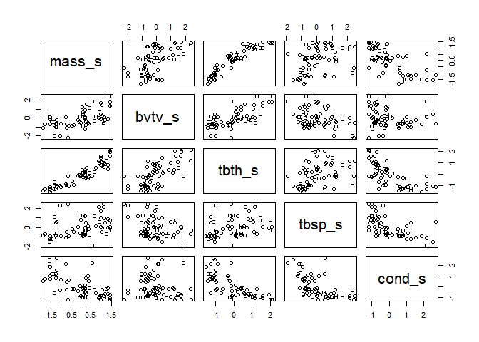

```r
d <- read.csv(file = "G:\\My Drive\\Philippine rodents\\Chrotomyini_brms\\04082022 Philippine Murids segmentation parameters and morphological data - TBA data total BoneJ (full).csv", header = T)

d <- d[d$tribe=="chroto",c(1:2, 4:22)]

d <-
  d %>%
  mutate(bvtv = as.numeric(bvtv))

d <-
  d %>%
  mutate(mass_s = rethinking::standardize(log10(mass_g)),
         elev_s = rethinking::standardize(elev),
         bvtv_s = rethinking::standardize(bvtv),
         tbth_s = rethinking::standardize(tbth),
         tbsp_s = rethinking::standardize(tbsp),
         conn_s = rethinking::standardize(conn),
         cond_s = rethinking::standardize(connd),
         da_s = rethinking::standardize(da))

# remove C. gonzalesi and R. isarogensis
d <-
  d %>%
  filter(taxon!="Chrotomys_gonzalesi") %>%
  filter(taxon!="Rhynchomys_isarogensis")

cols = c("#86acca","#ab685b", "#3370a3", "#1f314c","#5a9fa8")

d <-
  d %>%
  mutate(loco = factor(loco),
         hab_simp = factor(hab_simp),
         genus = factor(genus))
pairs(d[,c(22,24,25,26,28)])
```

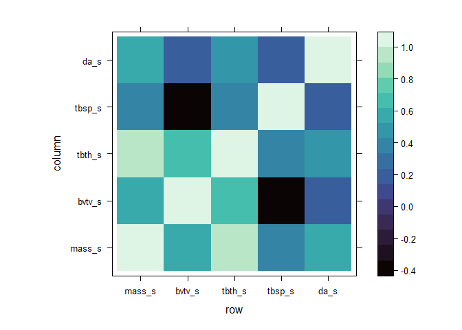

```r
dcov <- cov(d[,c(22,24,25,26,29)])
dcor <- cov2cor(dcov)
levelplot(dcor, col.regions = mako(100))
```

Load in phylogeny: REMEMBER: A <- ape::vcv.phylo(phylo), add corr = T if your tree is NOT SCALED TO 1.

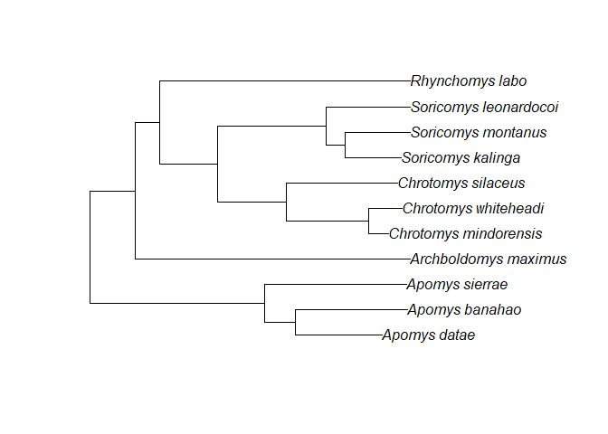

```r
ch.tre <- read.nexus(file = "G:\\My Drive\\Philippine rodents\\Chrotomys\\analysis\\SMS_PRUNED_and_COLLAPSED_03292022_OTUsrenamed_Rowsey_PhBgMCC_LzChrotomyini.nex")
plot(ch.tre)
```

```r
ch <- ape::vcv.phylo(ch.tre, corr = T)

d <-
  d %>%
  mutate(phylo = taxon)
```

Plot of Chrotomys only:

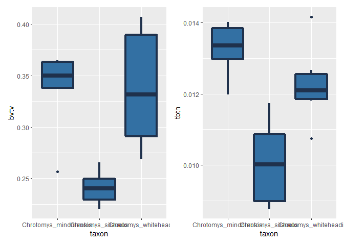

```r
chbvf<- d %>%
  filter(genus == "Chrotomys") %>%
  ggplot()+
  geom_boxplot(aes(x=taxon, y = bvtv), lwd = 1.5, fill = "#3370A3", color = "#1F314C")

chtbth<- d %>%
  filter(genus == "Chrotomys") %>%
  ggplot()+
  geom_boxplot(aes(x=taxon, y = tbth), lwd = 1.5, fill = "#3370A3", color = "#1F314C")

chtbsp<- d %>%
  filter(genus == "Chrotomys") %>%
  ggplot()+
  geom_boxplot(aes(x=taxon, y = tbsp), lwd = 1.5, fill = "#3370A3", color = "#1F314C")

chbvf|chtbth
```

Model of Chrotomys only:

```r
# Chrotomys only data set
chronly <- d %>%
  filter(genus == "Chrotomys")

# Chrotomys only tree
chron_tre <-keep.tip(ch.tre,ch.tre$tip.label[grep("Chrotomys",ch.tre$tip.label)])
chcov <- ape::vcv.phylo(chron_tre, corr = T)

# by taxon only
ch.45 <-
  brm(data = chronly,
      family = gaussian,
      bvtv_s ~ 0 + taxon,
      prior = c(prior(normal(0, 1), class = b),
                prior(exponential(1), class = sigma)),
      iter = 2000, warmup = 1000, chains = 4, cores = 4,
      file = "G:\\My Drive\\Philippine rodents\\Chrotomyini_brms\\fits\\ch.45")
print(ch.45)
```

```
##  Family: gaussian
##   Links: mu = identity; sigma = identity
## Formula: bvtv_s ~ 0 + taxon
##    Data: chronly (Number of observations: 19)
##   Draws: 4 chains, each with iter = 2000; warmup = 1000; thin = 1;
##          total post-warmup draws = 4000
##
## Population-Level Effects:
##                            Estimate Est.Error l-95% CI u-95% CI Rhat Bulk_ESS
## taxonChrotomys_mindorensis     1.20      0.28     0.62     1.75 1.00     4033
## taxonChrotomys_silaceus       -0.26      0.26    -0.76     0.26 1.00     4610
## taxonChrotomys_whiteheadi      1.20      0.28     0.63     1.73 1.00     4303
##                            Tail_ESS
## taxonChrotomys_mindorensis     2714
## taxonChrotomys_silaceus        3138
## taxonChrotomys_whiteheadi      2826
##
## Family Specific Parameters:
##       Estimate Est.Error l-95% CI u-95% CI Rhat Bulk_ESS Tail_ESS
## sigma     0.71      0.13     0.52     1.03 1.00     3114     2829
##
## Draws were sampled using sampling(NUTS). For each parameter, Bulk_ESS
## and Tail_ESS are effective sample size measures, and Rhat is the potential
## scale reduction factor on split chains (at convergence, Rhat = 1).
```

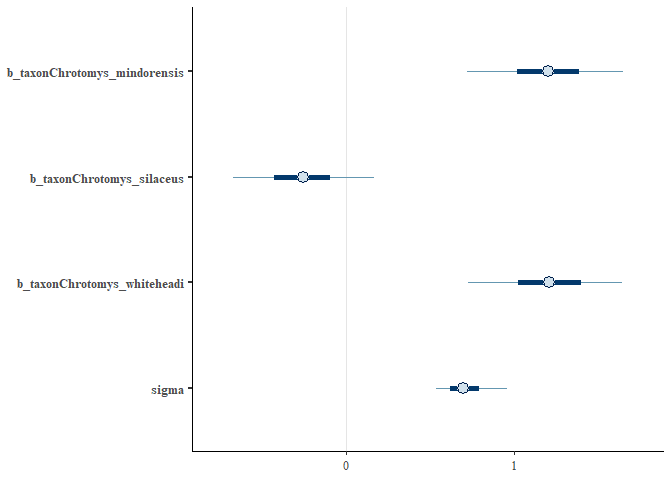

```r
mcmc_plot(ch.45)
```

```r
# by taxon plus mass
ch.46 <-
  brm(data = chronly,
      family = gaussian,
      bvtv_s ~ 0 + taxon + mass_s,
      prior = c(prior(normal(0, 1), class = b),
                prior(exponential(1), class = sigma)),
      iter = 2000, warmup = 1000, chains = 4, cores = 4,
      file = "G:\\My Drive\\Philippine rodents\\Chrotomyini_brms\\fits\\ch.46")
print(ch.46)
```

```
##  Family: gaussian
##   Links: mu = identity; sigma = identity
## Formula: bvtv_s ~ 0 + taxon + mass_s
##    Data: chronly (Number of observations: 19)
##   Draws: 4 chains, each with iter = 2000; warmup = 1000; thin = 1;
##          total post-warmup draws = 4000
##
## Population-Level Effects:
##                            Estimate Est.Error l-95% CI u-95% CI Rhat Bulk_ESS
## taxonChrotomys_mindorensis    -0.03      0.48    -0.93     0.93 1.00     1435
## taxonChrotomys_silaceus       -0.83      0.29    -1.39    -0.24 1.00     1728
## taxonChrotomys_whiteheadi      0.18      0.42    -0.63     1.00 1.00     1555
## mass_s                         1.05      0.35     0.36     1.73 1.00     1355
##                            Tail_ESS
## taxonChrotomys_mindorensis     1724
## taxonChrotomys_silaceus        1949
## taxonChrotomys_whiteheadi      2163
## mass_s                         1746
##
## Family Specific Parameters:
##       Estimate Est.Error l-95% CI u-95% CI Rhat Bulk_ESS Tail_ESS
## sigma     0.58      0.11     0.41     0.84 1.00     1718     1954
##
## Draws were sampled using sampling(NUTS). For each parameter, Bulk_ESS
## and Tail_ESS are effective sample size measures, and Rhat is the potential
## scale reduction factor on split chains (at convergence, Rhat = 1).
```

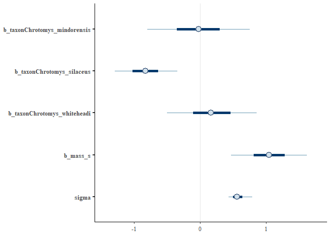

```r
mcmc_plot(ch.46)
```

```r
# by taxon plus mass plus phy/intrasp
ch.47 <-
  brm(data = chronly,
      family = gaussian,
      bvtv_s ~ 0 + taxon + mass_s + (1|gr(phylo, cov = chcov)) + (1|taxon),
      control = list(adapt_delta = 0.97), #inserted to decrease the number of divergent transitions here
      prior = c(
        prior(normal(0, 1), class = b, coef = taxonChrotomys_whiteheadi),
        prior(normal(0, 1), class = b, coef = taxonChrotomys_silaceus),
        prior(normal(0, 1), class = b, coef = taxonChrotomys_mindorensis),
        prior(normal(0, 1), class = b, coef = mass_s),
        prior(normal(0, 1), class = sd),
        prior(exponential(1), class = sigma)
        ),
      data2 = list(chcov = chcov),
      iter = 2000, warmup = 1000, chains = 4, cores = 4,
      file = "G:\\My Drive\\Philippine rodents\\Chrotomyini_brms\\fits\\ch.47")
print(ch.47)
```

```
##  Family: gaussian
##   Links: mu = identity; sigma = identity
## Formula: bvtv_s ~ 0 + taxon + mass_s + (1 | gr(phylo, cov = chcov)) + (1 | taxon)
##    Data: chronly (Number of observations: 19)
##   Draws: 4 chains, each with iter = 2000; warmup = 1000; thin = 1;
##          total post-warmup draws = 4000
##
## Group-Level Effects:
## ~phylo (Number of levels: 3)
##               Estimate Est.Error l-95% CI u-95% CI Rhat Bulk_ESS Tail_ESS
## sd(Intercept)     0.59      0.46     0.02     1.68 1.00     2526     2107
##
## ~taxon (Number of levels: 3)
##               Estimate Est.Error l-95% CI u-95% CI Rhat Bulk_ESS Tail_ESS
## sd(Intercept)     0.56      0.43     0.02     1.62 1.00     2262     1422
##
## Population-Level Effects:
##                            Estimate Est.Error l-95% CI u-95% CI Rhat Bulk_ESS
## taxonChrotomys_mindorensis    -0.06      0.70    -1.42     1.36 1.00     3201
## taxonChrotomys_silaceus       -0.50      0.67    -1.74     0.91 1.00     3108
## taxonChrotomys_whiteheadi      0.12      0.67    -1.24     1.41 1.00     3314
## mass_s                         1.07      0.39     0.25     1.81 1.00     3658
##                            Tail_ESS
## taxonChrotomys_mindorensis     2725
## taxonChrotomys_silaceus        2886
## taxonChrotomys_whiteheadi      2511
## mass_s                         2754
##
## Family Specific Parameters:
##       Estimate Est.Error l-95% CI u-95% CI Rhat Bulk_ESS Tail_ESS
## sigma     0.58      0.11     0.41     0.85 1.00     3670     2583
##
## Draws were sampled using sampling(NUTS). For each parameter, Bulk_ESS
## and Tail_ESS are effective sample size measures, and Rhat is the potential
## scale reduction factor on split chains (at convergence, Rhat = 1).
```

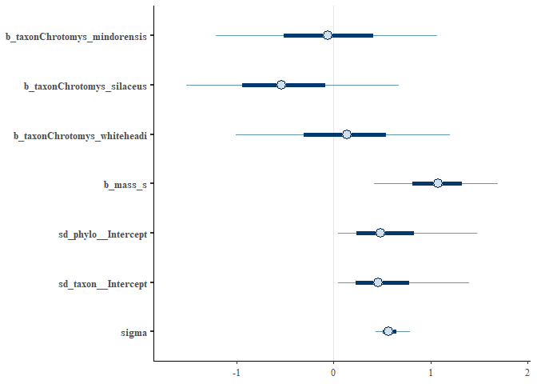

```r
mcmc_plot(ch.47)
```

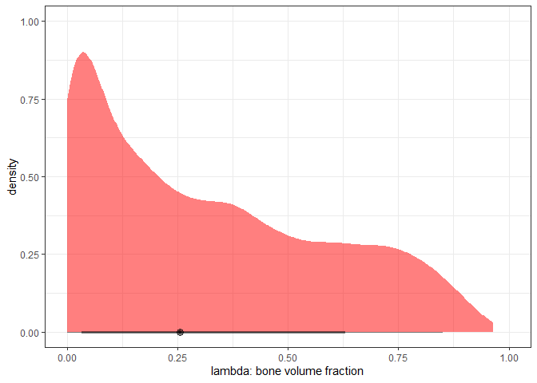

```r
hyp <- "sd_phylo__Intercept^2 / (sd_phylo__Intercept^2 + sd_taxon__Intercept^2 + sigma^2) = 0"
chrot.bvtv <- hypothesis(ch.47, hyp, class = NULL)
chrot.bvtv.pl <- ggplot() +
  stat_halfeye(aes(x = chrot.bvtv$samples$H1), fill = "red", alpha = 0.5) +
  theme_bw() +
  xlim(0,1) +
  labs(y = "density", x = "lambda: bone volume fraction")
chrot.bvtv.pl
```

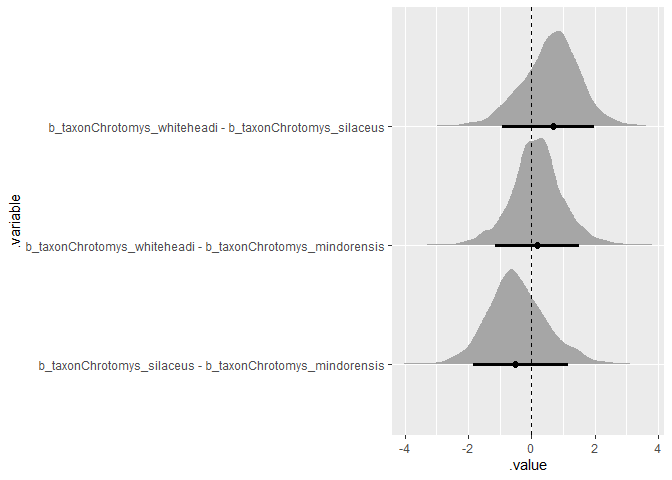

```r
ch.47 %>%
  gather_draws(b_taxonChrotomys_whiteheadi,b_taxonChrotomys_silaceus, b_taxonChrotomys_mindorensis) %>%
  compare_levels(.value, by = .variable) %>%
  ungroup() %>%
  #mutate(loco = reorder(.variable, .value)) %>%
  ggplot(aes(y = .variable, x = .value)) +
  stat_halfeye(.width = .89) +
  geom_vline(xintercept = 0, linetype = "dashed")
```

ch.24: compare bvtv across genera, no phylo or nothin

```r
ch.24 <-
  brm(data = d,
      family = gaussian,
      bvtv_s ~ 0 + genus,
      prior = c(prior(normal(0, 1), class = b),
                prior(exponential(1), class = sigma)),
      iter = 2000, warmup = 1000, chains = 4, cores = 4,
      seed = 5,
      file = "G:\\My Drive\\Philippine rodents\\Chrotomyini_brms\\fits\\ch.24")
print(ch.24)
```

```
##  Family: gaussian
##   Links: mu = identity; sigma = identity
## Formula: bvtv_s ~ 0 + genus
##    Data: d (Number of observations: 67)
##   Draws: 4 chains, each with iter = 2000; warmup = 1000; thin = 1;
##          total post-warmup draws = 4000
##
## Population-Level Effects:
##                   Estimate Est.Error l-95% CI u-95% CI Rhat Bulk_ESS Tail_ESS
## genusApomys           0.18      0.19    -0.21     0.56 1.00     5779     2647
## genusArchboldomys    -0.82      0.32    -1.43    -0.19 1.00     6098     3360
## genusChrotomys        0.69      0.19     0.33     1.06 1.00     6144     2987
## genusRhynchomys      -0.20      0.34    -0.85     0.45 1.00     5480     2936
## genusSoricomys       -0.63      0.19    -1.01    -0.25 1.00     5510     2876
##
## Family Specific Parameters:
##       Estimate Est.Error l-95% CI u-95% CI Rhat Bulk_ESS Tail_ESS
## sigma     0.84      0.08     0.70     1.00 1.00     5015     2956
##
## Draws were sampled using sampling(NUTS). For each parameter, Bulk_ESS
## and Tail_ESS are effective sample size measures, and Rhat is the potential
## scale reduction factor on split chains (at convergence, Rhat = 1).
```

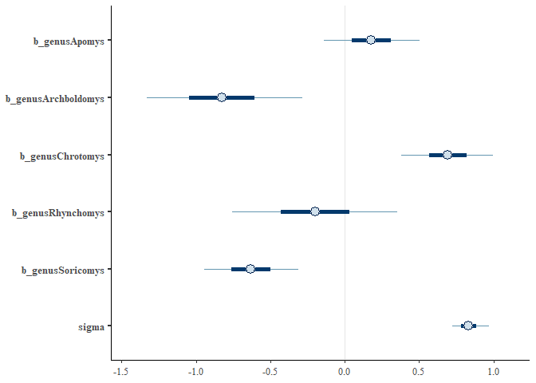

```r
mcmc_plot(ch.24)
```

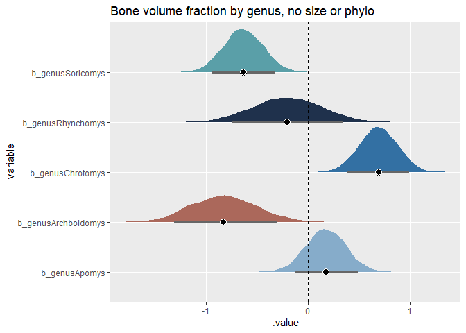

```r
ch.24 %>%
  gather_draws(b_genusApomys,b_genusArchboldomys, b_genusChrotomys, b_genusRhynchomys, b_genusSoricomys) %>%
  ggplot(aes(y = .variable, x = .value)) +
  stat_halfeye(aes(fill = .variable),
               point_fill = "#000000",
               shape = 21,
               point_size = 3,
               point_color = "#FFFFFF",
               interval_size = 7,
               interval_color = "grey40",
               .width = .89) +
  scale_fill_manual(values = cols)+
  theme(legend.position = "none")+
  geom_vline(xintercept = 0, linetype = "dashed")+
  ggtitle(label = "Bone volume fraction by genus, no size or phylo")
```

ch.25: compare bvtv across genera, mass but no phylo

```r
ch.25 <-
  brm(data = d,
      family = gaussian,
      bvtv_s ~ 0 + genus + mass_s,
      prior = c(prior(normal(0, 1), class = b),
                prior(exponential(1), class = sigma)),
      iter = 2000, warmup = 1000, chains = 4, cores = 4,
      seed = 5,
      file = "G:\\My Drive\\Philippine rodents\\Chrotomyini_brms\\fits\\ch.25")
print(ch.25)
```

```
##  Family: gaussian
##   Links: mu = identity; sigma = identity
## Formula: bvtv_s ~ 0 + genus + mass_s
##    Data: d (Number of observations: 67)
##   Draws: 4 chains, each with iter = 2000; warmup = 1000; thin = 1;
##          total post-warmup draws = 4000
##
## Population-Level Effects:
##                   Estimate Est.Error l-95% CI u-95% CI Rhat Bulk_ESS Tail_ESS
## genusApomys           0.06      0.17    -0.28     0.42 1.00     3220     2224
## genusArchboldomys    -0.26      0.33    -0.90     0.37 1.00     2355     2392
## genusChrotomys       -0.22      0.30    -0.78     0.38 1.00     1679     2052
## genusRhynchomys      -1.32      0.42    -2.10    -0.50 1.00     1809     2618
## genusSoricomys        0.70      0.40    -0.10     1.45 1.00     1512     2107
## mass_s                1.00      0.27     0.46     1.52 1.00     1389     1970
##
## Family Specific Parameters:
##       Estimate Est.Error l-95% CI u-95% CI Rhat Bulk_ESS Tail_ESS
## sigma     0.74      0.07     0.62     0.90 1.00     3381     2588
##
## Draws were sampled using sampling(NUTS). For each parameter, Bulk_ESS
## and Tail_ESS are effective sample size measures, and Rhat is the potential
## scale reduction factor on split chains (at convergence, Rhat = 1).
```

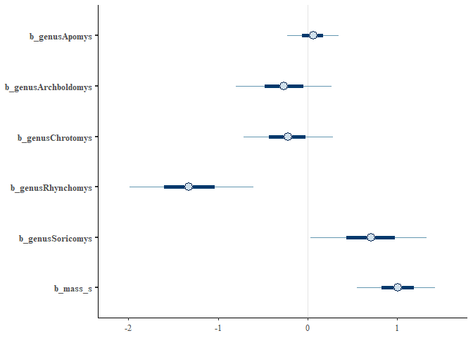

```r
mcmc_plot(ch.25, "^b_", regex = T)
```

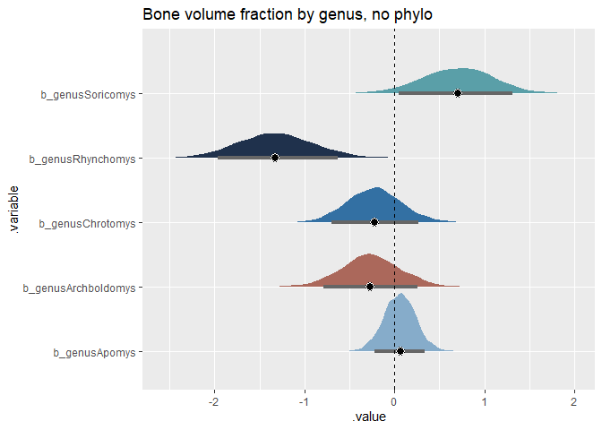

```r
ch.25 %>%
  gather_draws(b_genusApomys,b_genusArchboldomys, b_genusChrotomys, b_genusRhynchomys, b_genusSoricomys) %>%
  ggplot(aes(y = .variable, x = .value)) +
  stat_halfeye(aes(fill = .variable),
               point_fill = "#000000",
               shape = 21,
               point_size = 3,
               point_color = "#FFFFFF",
               interval_size = 7,
               interval_color = "grey40",
               .width = .89) +
  scale_fill_manual(values = cols)+
  theme(legend.position = "none")+
  geom_vline(xintercept = 0, linetype = "dashed")+
  ggtitle(label = "Bone volume fraction by genus, no phylo")
```

…this is not at all what I expected?

ch.26: bvtv by genus + mass, Include phylo and intraspec:

```r
ch.26 <-
  brm(data = d,
      family = gaussian,
      bvtv_s ~ 0 + genus + mass_s + (1|gr(phylo, cov = ch)) + (1|taxon),
      control = list(adapt_delta = 0.85), #inserted to decrease the number of divergent transitions here
      prior = c(
        prior(normal(0, 1), class = b, coef = genusApomys),
        prior(normal(0, 1), class = b, coef = genusArchboldomys),
        prior(normal(0, 1), class = b, coef = genusChrotomys),
        prior(normal(0, 1), class = b, coef = genusRhynchomys),
        prior(normal(0, 1), class = b, coef = genusSoricomys),
        prior(normal(0, 1), class = b, coef = mass_s),
        prior(normal(0, 1), class = sd),
        prior(exponential(1), class = sigma)
        ),
      data2 = list(ch = ch),
      iter = 2000, warmup = 1000, chains = 4, cores = 4,
      file = "G:\\My Drive\\Philippine rodents\\Chrotomyini_brms\\fits\\ch.26")

ch.26 <- add_criterion(ch.26, "waic")
ch.26 <- add_criterion(ch.26, "loo")

print(ch.26)
```

```
##  Family: gaussian
##   Links: mu = identity; sigma = identity
## Formula: bvtv_s ~ 0 + genus + mass_s + (1 | gr(phylo, cov = ch)) + (1 | taxon)
##    Data: d (Number of observations: 67)
##   Draws: 4 chains, each with iter = 2000; warmup = 1000; thin = 1;
##          total post-warmup draws = 4000
##
## Group-Level Effects:
## ~phylo (Number of levels: 11)
##               Estimate Est.Error l-95% CI u-95% CI Rhat Bulk_ESS Tail_ESS
## sd(Intercept)     0.50      0.32     0.03     1.19 1.00     1273     2007
##
## ~taxon (Number of levels: 11)
##               Estimate Est.Error l-95% CI u-95% CI Rhat Bulk_ESS Tail_ESS
## sd(Intercept)     0.36      0.24     0.02     0.91 1.00     1039     1655
##
## Population-Level Effects:
##                   Estimate Est.Error l-95% CI u-95% CI Rhat Bulk_ESS Tail_ESS
## genusApomys           0.07      0.48    -0.92     1.04 1.00     3331     2470
## genusArchboldomys    -0.27      0.61    -1.44     0.98 1.00     3997     2763
## genusChrotomys       -0.02      0.55    -1.12     1.07 1.00     3260     2484
## genusRhynchomys      -0.78      0.65    -2.00     0.54 1.00     3363     2894
## genusSoricomys        0.35      0.61    -0.88     1.57 1.00     3543     2774
## mass_s                0.78      0.31     0.16     1.41 1.00     3657     3065
##
## Family Specific Parameters:
##       Estimate Est.Error l-95% CI u-95% CI Rhat Bulk_ESS Tail_ESS
## sigma     0.67      0.07     0.56     0.82 1.00     4037     2400
##
## Draws were sampled using sampling(NUTS). For each parameter, Bulk_ESS
## and Tail_ESS are effective sample size measures, and Rhat is the potential
## scale reduction factor on split chains (at convergence, Rhat = 1).
```

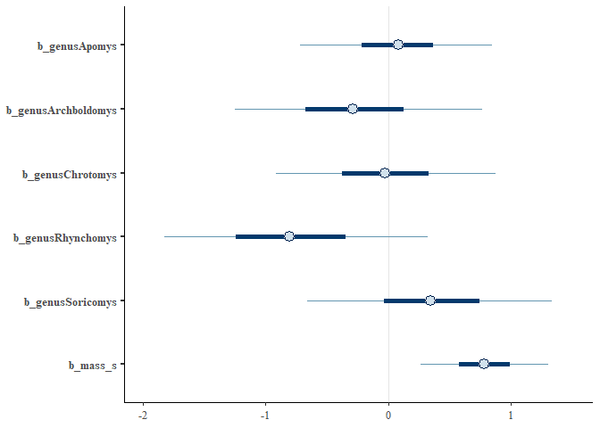

```r
mcmc_plot(ch.26, "^b_", regex = T)
```

Halfeye plot:

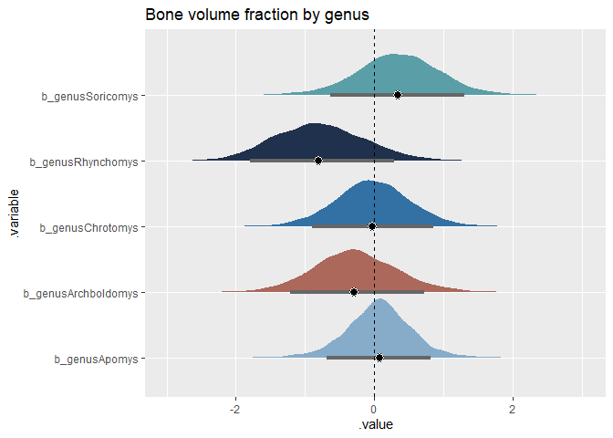

```r
ch.26 %>%
  gather_draws(b_genusApomys,b_genusArchboldomys, b_genusChrotomys, b_genusRhynchomys, b_genusSoricomys) %>%
  ggplot(aes(y = .variable, x = .value)) +
  stat_halfeye(aes(fill = .variable),
               point_fill = "#000000",
               shape = 21,
               point_size = 3,
               point_color = "#FFFFFF",
               interval_size = 7,
               interval_color = "grey40",
               .width = .89) +
  scale_fill_manual(values = cols)+
  theme(legend.position = "none")+
  geom_vline(xintercept = 0, linetype = "dashed")+
  ggtitle(label = "Bone volume fraction by genus")
```

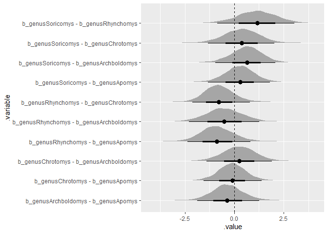

```r
ch.26 %>%
  gather_draws(b_genusApomys,b_genusArchboldomys, b_genusChrotomys, b_genusRhynchomys, b_genusSoricomys) %>%
  compare_levels(.value, by = .variable) %>%
  ungroup() %>%
  mutate(loco = reorder(.variable, .value)) %>%
  ggplot(aes(y = .variable, x = .value)) +
  stat_halfeye() +
  geom_vline(xintercept = 0, linetype = "dashed")
```

Combined halfeye plot of gradual addition of features to the model:

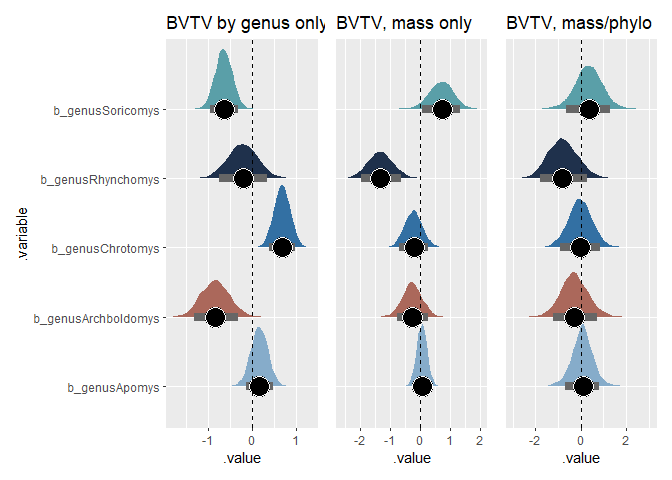

```r
nomass_halfeye <- ch.24 %>%
  gather_draws(b_genusApomys,b_genusArchboldomys, b_genusChrotomys, b_genusRhynchomys, b_genusSoricomys) %>%
  ggplot(aes(y = .variable, x = .value)) +
  stat_halfeye(aes(fill = .variable),
               point_fill = "#000000",
               shape = 21,
               point_size = 7,
               point_color = "#FFFFFF",
               interval_size = 15,
               interval_color = "grey40",
               .width = .89) +
  scale_fill_manual(values = cols)+
  geom_vline(xintercept = 0, linetype = "dashed")+
  theme(legend.position = "none")+
  ggtitle(label = "BVTV by genus only")

nophy_halfeye <- ch.25 %>%
  gather_draws(b_genusApomys,b_genusArchboldomys, b_genusChrotomys, b_genusRhynchomys, b_genusSoricomys) %>%
  ggplot(aes(y = .variable, x = .value)) +
  stat_halfeye(aes(fill = .variable),
               point_fill = "#000000",
               shape = 21,
               point_size = 7,
               point_color = "#FFFFFF",
               interval_size = 15,
               interval_color = "grey40",
               .width = .89) +
  scale_fill_manual(values = cols)+
  geom_vline(xintercept = 0, linetype = "dashed")+
  ggtitle(label = "BVTV, mass only")+
  theme(legend.position = "none",
        axis.text.y = element_blank(),
        axis.ticks.y = element_blank(),
        axis.title.y = element_blank())

all_halfeye <- ch.26 %>%
  gather_draws(b_genusApomys,b_genusArchboldomys, b_genusChrotomys, b_genusRhynchomys, b_genusSoricomys) %>%
  ggplot(aes(y = .variable, x = .value)) +
  stat_halfeye(aes(fill = .variable),
               point_fill = "#000000",
               shape = 21,
               point_size = 7,
               point_color = "#FFFFFF",
               interval_size = 15,
               interval_color = "grey40",
               .width = .89) +
  scale_fill_manual(values = cols)+
  geom_vline(xintercept = 0, linetype = "dashed")+
  ggtitle(label = "BVTV, mass/phylo")+
  theme(legend.position = "none",
        axis.text.y = element_blank(),
        axis.ticks.y = element_blank(),
        axis.title.y = element_blank())

nomass_halfeye | nophy_halfeye | all_halfeye
```

```r
loo(ch.26) # only one k above 0.5
```

```
##
## Computed from 4000 by 67 log-likelihood matrix
##
##          Estimate   SE
## elpd_loo    -74.6  6.6
## p_loo        10.8  2.0
## looic       149.1 13.3
## ------
## Monte Carlo SE of elpd_loo is 0.1.
##
## Pareto k diagnostic values:
##                          Count Pct.    Min. n_eff
## (-Inf, 0.5]   (good)     66    98.5%   1034
##  (0.5, 0.7]   (ok)        1     1.5%   310
##    (0.7, 1]   (bad)       0     0.0%   <NA>
##    (1, Inf)   (very bad)  0     0.0%   <NA>
##
## All Pareto k estimates are ok (k < 0.7).
## See help('pareto-k-diagnostic') for details.
```

```r
tibble(k   = ch.26$criteria$loo$diagnostics$pareto_k,
       row = 1:67,
       specimen = paste(d$specno[row], d$taxon[row])) %>%
  arrange(desc(k))
```

```
## # A tibble: 67 x 3
##        k   row specimen
##    <dbl> <int> <chr>
##  1 0.693    16 216462 Apomys_sierrae
##  2 0.495    19 193523 Archboldomys_maximus
##  3 0.423    62 188313 Soricomys_montanus
##  4 0.418    26 221833 Chrotomys_mindorensis
##  5 0.417     3 218312 Apomys_banahao
##  6 0.416    22 193526 Archboldomys_maximus
##  7 0.409    43 193744 Chrotomys_whiteheadi
##  8 0.406    60 190968 Soricomys_leonardocoi
##  9 0.364    14 216435 Apomys_sierrae
## 10 0.357    20 193524 Archboldomys_maximus
## # ... with 57 more rows
```

ch.27: tbth by genus, Include phylo and intraspec:

```r
ch.27 <-
  brm(data = d,
      family = gaussian,
      tbth_s ~ 0 + genus + mass_s + (1|gr(phylo, cov = ch)) + (1|taxon),
      control = list(adapt_delta = 0.95), #inserted to decrease the number of divergent transitions here
      prior = c(
        prior(normal(0, 1), class = b, coef = genusApomys),
        prior(normal(0, 1), class = b, coef = genusArchboldomys),
        prior(normal(0, 1), class = b, coef = genusChrotomys),
        prior(normal(0, 1), class = b, coef = genusRhynchomys),
        prior(normal(0, 1), class = b, coef = genusSoricomys),
        prior(normal(0, 1), class = b, coef = mass_s),
        prior(normal(0, 1), class = sd),
        prior(exponential(1), class = sigma)
        ),
      data2 = list(ch = ch),
      iter = 2000, warmup = 1000, chains = 4, cores = 4,
      file = "G:\\My Drive\\Philippine rodents\\Chrotomyini_brms\\fits\\ch.27")

print(ch.27)
```

```
##  Family: gaussian
##   Links: mu = identity; sigma = identity
## Formula: tbth_s ~ 0 + genus + mass_s + (1 | gr(phylo, cov = ch)) + (1 | taxon)
##    Data: d (Number of observations: 67)
##   Draws: 4 chains, each with iter = 2000; warmup = 1000; thin = 1;
##          total post-warmup draws = 4000
##
## Group-Level Effects:
## ~phylo (Number of levels: 11)
##               Estimate Est.Error l-95% CI u-95% CI Rhat Bulk_ESS Tail_ESS
## sd(Intercept)     0.34      0.21     0.02     0.81 1.00     1158     1269
##
## ~taxon (Number of levels: 11)
##               Estimate Est.Error l-95% CI u-95% CI Rhat Bulk_ESS Tail_ESS
## sd(Intercept)     0.20      0.14     0.01     0.54 1.00     1113     1782
##
## Population-Level Effects:
##                   Estimate Est.Error l-95% CI u-95% CI Rhat Bulk_ESS Tail_ESS
## genusApomys          -0.08      0.35    -0.76     0.66 1.00     2315     1585
## genusArchboldomys    -0.20      0.42    -1.03     0.65 1.00     2973     2656
## genusChrotomys        0.11      0.38    -0.65     0.86 1.00     2532     2370
## genusRhynchomys      -0.27      0.45    -1.08     0.68 1.00     2924     2627
## genusSoricomys        0.09      0.40    -0.74     0.88 1.00     3042     2431
## mass_s                0.93      0.16     0.62     1.23 1.00     3138     3354
##
## Family Specific Parameters:
##       Estimate Est.Error l-95% CI u-95% CI Rhat Bulk_ESS Tail_ESS
## sigma     0.28      0.03     0.23     0.34 1.00     3973     2736
##
## Draws were sampled using sampling(NUTS). For each parameter, Bulk_ESS
## and Tail_ESS are effective sample size measures, and Rhat is the potential
## scale reduction factor on split chains (at convergence, Rhat = 1).
```

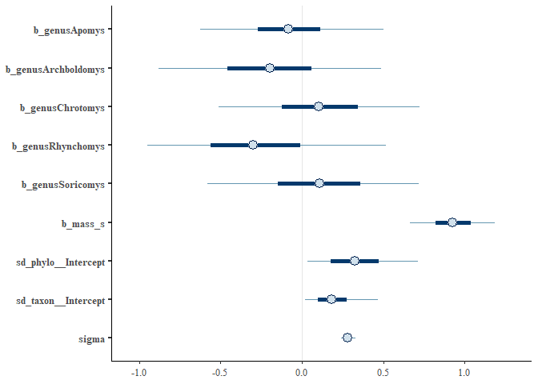

```r
mcmc_plot(ch.27)
```

```r
ch.27 <- add_criterion(ch.27, "waic")
ch.27 <- add_criterion(ch.27, "loo")

loo(ch.27) #only one k above 0.5
```

```
##
## Computed from 4000 by 67 log-likelihood matrix
##
##          Estimate   SE
## elpd_loo    -16.5  5.7
## p_loo        11.4  1.8
## looic        33.0 11.5
## ------
## Monte Carlo SE of elpd_loo is 0.1.
##
## Pareto k diagnostic values:
##                          Count Pct.    Min. n_eff
## (-Inf, 0.5]   (good)     66    98.5%   578
##  (0.5, 0.7]   (ok)        1     1.5%   1517
##    (0.7, 1]   (bad)       0     0.0%   <NA>
##    (1, Inf)   (very bad)  0     0.0%   <NA>
##
## All Pareto k estimates are ok (k < 0.7).
## See help('pareto-k-diagnostic') for details.
```

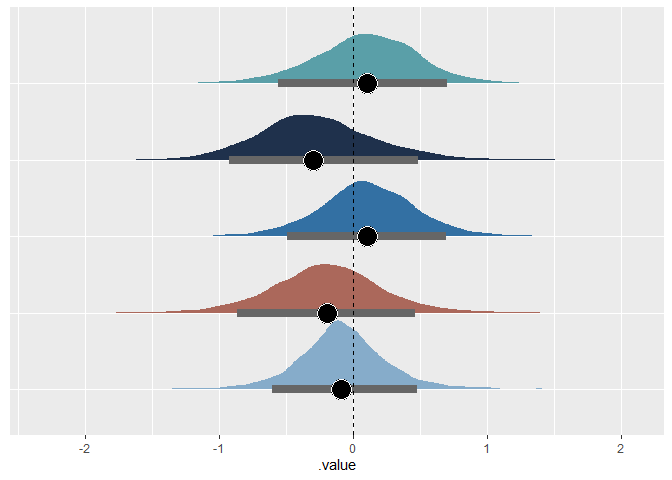

```r
ch.27 %>%
  gather_draws(b_genusApomys,b_genusArchboldomys, b_genusChrotomys, b_genusRhynchomys, b_genusSoricomys) %>%
  ggplot(aes(y = .variable, x = .value)) +
  stat_halfeye(aes(fill = .variable),
               point_fill = "#000000",
               shape = 21,
               point_size = 7,
               point_color = "#FFFFFF",
               interval_size = 15,
               interval_color = "grey40",
               .width = .89) +
  scale_fill_manual(values = cols)+
  geom_vline(xintercept = 0, linetype = "dashed")+
  #ggtitle(label = "tbth by genus")+
  theme(legend.position = "none",
        axis.text.y = element_blank(),
        axis.ticks.y = element_blank(),
        axis.title.y = element_blank())
```

ch.28: da by genus, Include phylo and intraspec:

```r
ch.28 <-
  brm(data = d,
      family = gaussian,
      da_s ~ 0 + genus + mass_s + (1|gr(phylo, cov = ch)) + (1|taxon),
      control = list(adapt_delta = 0.95), #inserted to decrease the number of divergent transitions here
      prior = c(
        prior(normal(0, 1), class = b, coef = genusApomys),
        prior(normal(0, 1), class = b, coef = genusArchboldomys),
        prior(normal(0, 1), class = b, coef = genusChrotomys),
        prior(normal(0, 1), class = b, coef = genusRhynchomys),
        prior(normal(0, 1), class = b, coef = genusSoricomys),
        prior(normal(0, 1), class = b, coef = mass_s),
        prior(normal(0, 1), class = sd),
        prior(exponential(1), class = sigma)
        ),
      data2 = list(ch = ch),
      iter = 2000, warmup = 1000, chains = 4, cores = 4,
      file = "G:\\My Drive\\Philippine rodents\\Chrotomyini_brms\\fits\\ch.28")

print(ch.28)
```

```
##  Family: gaussian
##   Links: mu = identity; sigma = identity
## Formula: da_s ~ 0 + genus + mass_s + (1 | gr(phylo, cov = ch)) + (1 | taxon)
##    Data: d (Number of observations: 67)
##   Draws: 4 chains, each with iter = 2000; warmup = 1000; thin = 1;
##          total post-warmup draws = 4000
##
## Group-Level Effects:
## ~phylo (Number of levels: 11)
##               Estimate Est.Error l-95% CI u-95% CI Rhat Bulk_ESS Tail_ESS
## sd(Intercept)     0.48      0.35     0.02     1.27 1.00     1108     1761
##
## ~taxon (Number of levels: 11)
##               Estimate Est.Error l-95% CI u-95% CI Rhat Bulk_ESS Tail_ESS
## sd(Intercept)     0.47      0.23     0.04     0.97 1.00     1181     1204
##
## Population-Level Effects:
##                   Estimate Est.Error l-95% CI u-95% CI Rhat Bulk_ESS Tail_ESS
## genusApomys           0.52      0.50    -0.57     1.47 1.00     2946     2623
## genusArchboldomys     0.18      0.61    -1.02     1.38 1.00     3641     2926
## genusChrotomys        0.32      0.53    -0.76     1.35 1.00     2932     2311
## genusRhynchomys       0.24      0.63    -1.02     1.45 1.00     3094     2808
## genusSoricomys       -1.00      0.60    -2.08     0.28 1.00     2417     2044
## mass_s                0.04      0.27    -0.48     0.55 1.00     3339     2890
##
## Family Specific Parameters:
##       Estimate Est.Error l-95% CI u-95% CI Rhat Bulk_ESS Tail_ESS
## sigma     0.51      0.05     0.42     0.61 1.00     4345     2580
##
## Draws were sampled using sampling(NUTS). For each parameter, Bulk_ESS
## and Tail_ESS are effective sample size measures, and Rhat is the potential
## scale reduction factor on split chains (at convergence, Rhat = 1).
```

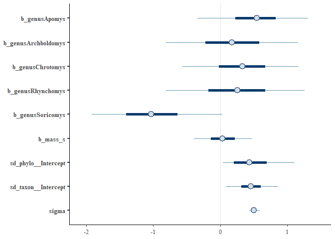

```r
mcmc_plot(ch.28)
```

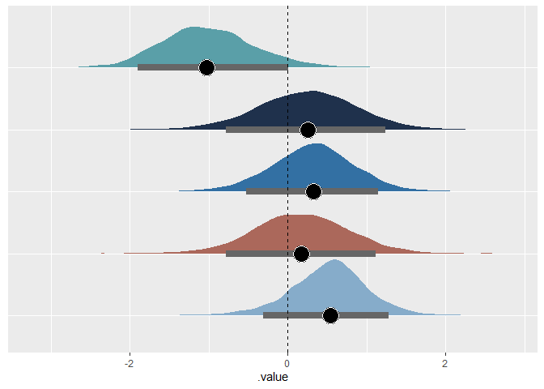

```r
ch.28 %>%
  gather_draws(b_genusApomys,b_genusArchboldomys, b_genusChrotomys, b_genusRhynchomys, b_genusSoricomys) %>%
  ggplot(aes(y = .variable, x = .value)) +
  stat_halfeye(aes(fill = .variable),
               point_fill = "#000000",
               shape = 21,
               point_size = 7,
               point_color = "#FFFFFF",
               interval_size = 15,
               interval_color = "grey40",
               .width = .89) +
  scale_fill_manual(values = cols)+
  geom_vline(xintercept = 0, linetype = "dashed")+
  #ggtitle(label = "da by genus")+
  theme(legend.position = "none",
        axis.text.y = element_blank(),
        axis.ticks.y = element_blank(),
        axis.title.y = element_blank())
```

A very striking difference in Soricomys!!!

ch.29: tbsp by genus, Include phylo and intraspec:

```r
ch.29 <-
  brm(data = d,
      family = gaussian,
      tbsp_s ~ 0 + genus + mass_s + (1|gr(phylo, cov = ch)) + (1|taxon),
      control = list(adapt_delta = 0.95), #inserted to decrease the number of divergent transitions here
      prior = c(
        prior(normal(0, 1), class = b, coef = genusApomys),
        prior(normal(0, 1), class = b, coef = genusArchboldomys),
        prior(normal(0, 1), class = b, coef = genusChrotomys),
        prior(normal(0, 1), class = b, coef = genusRhynchomys),
        prior(normal(0, 1), class = b, coef = genusSoricomys),
        prior(normal(0, 1), class = b, coef = mass_s),
        prior(normal(0, 1), class = sd),
        prior(exponential(1), class = sigma)
        ),
      data2 = list(ch = ch),
      iter = 2000, warmup = 1000, chains = 4, cores = 4,
      file = "G:\\My Drive\\Philippine rodents\\Chrotomyini_brms\\fits\\ch.29")

print(ch.29)
```

```
##  Family: gaussian
##   Links: mu = identity; sigma = identity
## Formula: tbsp_s ~ 0 + genus + mass_s + (1 | gr(phylo, cov = ch)) + (1 | taxon)
##    Data: d (Number of observations: 67)
##   Draws: 4 chains, each with iter = 2000; warmup = 1000; thin = 1;
##          total post-warmup draws = 4000
##
## Group-Level Effects:
## ~phylo (Number of levels: 11)
##               Estimate Est.Error l-95% CI u-95% CI Rhat Bulk_ESS Tail_ESS
## sd(Intercept)     0.40      0.30     0.02     1.13 1.00     1585     2449
##
## ~taxon (Number of levels: 11)
##               Estimate Est.Error l-95% CI u-95% CI Rhat Bulk_ESS Tail_ESS
## sd(Intercept)     0.31      0.22     0.01     0.80 1.00     1356     1850
##
## Population-Level Effects:
##                   Estimate Est.Error l-95% CI u-95% CI Rhat Bulk_ESS Tail_ESS
## genusApomys          -0.17      0.44    -1.01     0.75 1.00     2923     2094
## genusArchboldomys     0.00      0.57    -1.15     1.14 1.00     3581     3042
## genusChrotomys        0.10      0.50    -0.92     1.10 1.00     3162     2772
## genusRhynchomys       0.46      0.65    -0.88     1.69 1.00     3243     2658
## genusSoricomys       -0.08      0.59    -1.26     1.12 1.00     2970     2643
## mass_s                0.27      0.34    -0.42     0.90 1.00     3013     3038
##
## Family Specific Parameters:
##       Estimate Est.Error l-95% CI u-95% CI Rhat Bulk_ESS Tail_ESS
## sigma     0.91      0.09     0.76     1.10 1.00     3890     2889
##
## Draws were sampled using sampling(NUTS). For each parameter, Bulk_ESS
## and Tail_ESS are effective sample size measures, and Rhat is the potential
## scale reduction factor on split chains (at convergence, Rhat = 1).
```

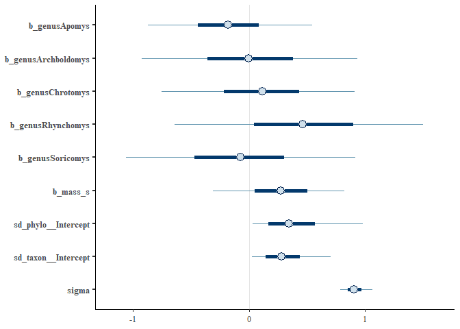

```r
mcmc_plot(ch.29)
```

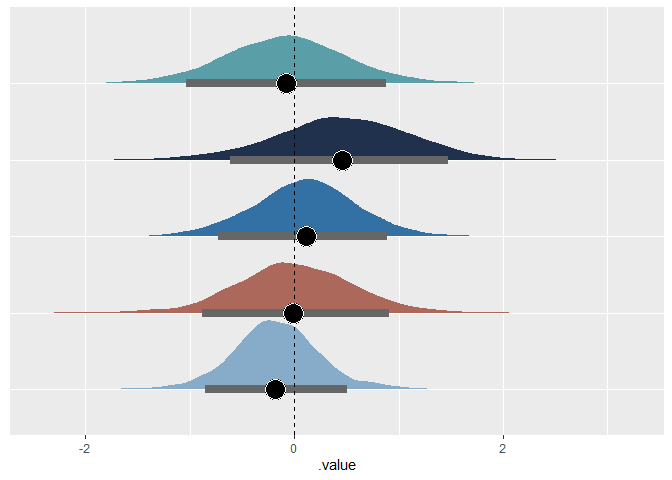

```r
ch.29 %>%
  gather_draws(b_genusApomys,b_genusArchboldomys, b_genusChrotomys, b_genusRhynchomys, b_genusSoricomys) %>%
  ggplot(aes(y = .variable, x = .value)) +
  stat_halfeye(aes(fill = .variable),
               point_fill = "#000000",
               shape = 21,
               point_size = 7,
               point_color = "#FFFFFF",
               interval_size = 15,
               interval_color = "grey40",
               .width = .89) +
  scale_fill_manual(values = cols)+
  geom_vline(xintercept = 0, linetype = "dashed")+
  #ggtitle(label = "tbsp by genus")+
  theme(legend.position = "none",
        axis.text.y = element_blank(),
        axis.ticks.y = element_blank(),
        axis.title.y = element_blank())
```

Compile effects of mass across all different metrics:

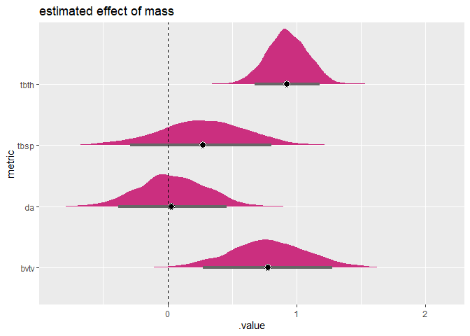

```r
gm.bvtv <- ch.26 %>%
  gather_draws(b_mass_s) %>%
  mutate(metric = "bvtv")

gm.tbth <- ch.27 %>%
  gather_draws(b_mass_s) %>%
  mutate(metric = "tbth")

gm.tbsp <- ch.29 %>%
  gather_draws(b_mass_s) %>%
  mutate(metric = "tbsp")

gm.da <- ch.28 %>%
  gather_draws(b_mass_s) %>%
  mutate(metric = "da")

gmass_b_all <- bind_rows(gm.bvtv, gm.tbth, gm.tbsp, gm.da)

gmass.pl <-   gmass_b_all %>%
  ggplot(aes(y = metric, x = .value)) +
  stat_halfeye(aes(fill = .variable),
               point_fill = "#000000",
               shape = 21,
               point_size = 3,
               point_color = "#FFFFFF",
               interval_size = 7,
               interval_color = "grey40",
               .width = .89) +
  scale_fill_manual(values = "#CB2F7F")+
  theme(legend.position = "none")+
  geom_vline(xintercept = 0, linetype = "dashed")+
  ggtitle(label = "estimated effect of mass")
gmass.pl
```

Compile phylogenetic sd across all metrics:

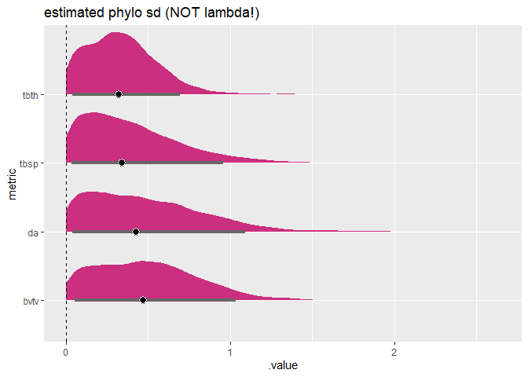

```r
gph.bvtv <- ch.26 %>%
  gather_draws(sd_phylo__Intercept) %>%
  mutate(metric = "bvtv")

gph.tbth <- ch.27 %>%
  gather_draws(sd_phylo__Intercept) %>%
  mutate(metric = "tbth")

gph.tbsp <- ch.29 %>%
  gather_draws(sd_phylo__Intercept) %>%
  mutate(metric = "tbsp")

gph.da <- ch.28 %>%
  gather_draws(sd_phylo__Intercept) %>%
  mutate(metric = "da")

gphylo_sd_all <- bind_rows(gph.bvtv, gph.tbth, gph.tbsp, gph.da)

gph.pl <-   gphylo_sd_all %>%
  ggplot(aes(y = metric, x = .value)) +
  stat_halfeye(aes(fill = .variable),
               point_fill = "#000000",
               shape = 21,
               point_size = 3,
               point_color = "#FFFFFF",
               interval_size = 7,
               interval_color = "grey40",
               .width = .89) +
  scale_fill_manual(values = "#CB2F7F")+
  theme(legend.position = "none")+
  geom_vline(xintercept = 0, linetype = "dashed")+
  ggtitle(label = "estimated phylo sd (NOT lambda!)")
gph.pl
```

Do one for phylogenetic signal:

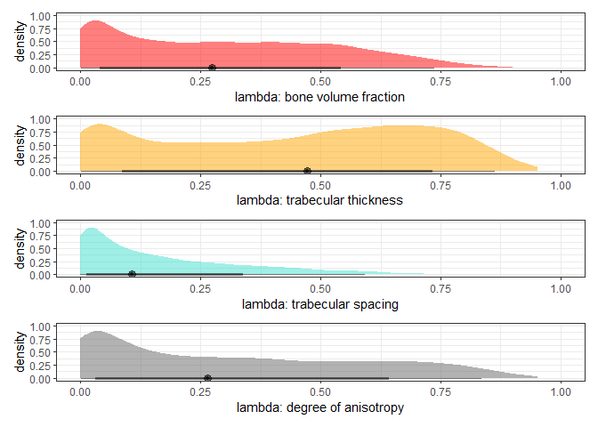

```r
hyp <- "sd_phylo__Intercept^2 / (sd_phylo__Intercept^2 + sd_taxon__Intercept^2 + sigma^2) = 0"
h.bvtv <- hypothesis(ch.26, hyp, class = NULL)
h.tbth <- hypothesis(ch.27, hyp, class = NULL)
h.tbsp <- hypothesis(ch.29, hyp, class = NULL)
h.da <- hypothesis(ch.28, hyp, class = NULL)

ph.bvtv.pl <- ggplot() +
  stat_halfeye(aes(x = h.bvtv$samples$H1), fill = "red", alpha = 0.5) +
  theme_bw() +
  xlim(0,1) +
  labs(y = "density", x = "lambda: bone volume fraction")

ph.tbth.pl <- ggplot() +
  stat_halfeye(aes(x = h.tbth$samples$H1), fill = "orange", alpha = 0.5)+
  theme_bw() +
  xlim(0,1)+
  labs(y = "density", x = "lambda: trabecular thickness")

ph.tbsp.pl <- ggplot() +
  stat_halfeye(aes(x = h.tbsp$samples$H1), fill = "turquoise", alpha = 0.5)+
  theme_bw() +
  xlim(0,1) +
  labs(y = "density", x = "lambda: trabecular spacing")

ph.da.pl <- ggplot()+
  stat_halfeye(aes(x = h.da$samples$H1), fill = "grey40", alpha = 0.5) +
  theme_bw() +
  xlim(0,1)+
  labs(y = "density", x = "lambda: degree of anisotropy")

ph.bvtv.pl/ph.tbth.pl/ph.tbsp.pl/ph.da.pl
```

Let’s do some analyses that don’t include mass as a covariate, but DO include phylogeny.

Bone volume fraction:

```r
ch.44 <-
  brm(data = d,
      family = gaussian,
      bvtv_s ~ 0 + genus + (1|gr(phylo, cov = ch)) + (1|taxon),
      control = list(adapt_delta = 0.89), #inserted to decrease the number of divergent transitions here
      prior = c(
        prior(normal(0, 1), class = b, coef = genusApomys),
        prior(normal(0, 1), class = b, coef = genusArchboldomys),
        prior(normal(0, 1), class = b, coef = genusChrotomys),
        prior(normal(0, 1), class = b, coef = genusRhynchomys),
        prior(normal(0, 1), class = b, coef = genusSoricomys),
        prior(normal(0, 1), class = sd),
        prior(exponential(1), class = sigma)
        ),
      data2 = list(ch = ch),
      iter = 2000, warmup = 1000, chains = 4, cores = 4,
      file = "G:\\My Drive\\Philippine rodents\\Chrotomyini_brms\\fits\\ch.44")

ch.44 <- add_criterion(ch.44, "waic")
ch.44 <- add_criterion(ch.44, "loo")

print(ch.44)
```

```
##  Family: gaussian
##   Links: mu = identity; sigma = identity
## Formula: bvtv_s ~ 0 + genus + (1 | gr(phylo, cov = ch)) + (1 | taxon)
##    Data: d (Number of observations: 67)
##   Draws: 4 chains, each with iter = 2000; warmup = 1000; thin = 1;
##          total post-warmup draws = 4000
##
## Group-Level Effects:
## ~phylo (Number of levels: 11)
##               Estimate Est.Error l-95% CI u-95% CI Rhat Bulk_ESS Tail_ESS
## sd(Intercept)     0.62      0.36     0.04     1.37 1.00     1133     1770
##
## ~taxon (Number of levels: 11)
##               Estimate Est.Error l-95% CI u-95% CI Rhat Bulk_ESS Tail_ESS
## sd(Intercept)     0.40      0.27     0.01     1.00 1.00     1019     1542
##
## Population-Level Effects:
##                   Estimate Est.Error l-95% CI u-95% CI Rhat Bulk_ESS Tail_ESS
## genusApomys           0.13      0.54    -1.00     1.18 1.00     3425     2716
## genusArchboldomys    -0.55      0.65    -1.78     0.77 1.00     4065     3026
## genusChrotomys        0.56      0.55    -0.59     1.64 1.00     3648     2616
## genusRhynchomys      -0.13      0.65    -1.41     1.15 1.00     4472     2900
## genusSoricomys       -0.48      0.55    -1.52     0.63 1.00     3431     2942
##
## Family Specific Parameters:
##       Estimate Est.Error l-95% CI u-95% CI Rhat Bulk_ESS Tail_ESS
## sigma     0.70      0.07     0.58     0.85 1.00     5518     3021
##
## Draws were sampled using sampling(NUTS). For each parameter, Bulk_ESS
## and Tail_ESS are effective sample size measures, and Rhat is the potential
## scale reduction factor on split chains (at convergence, Rhat = 1).
```

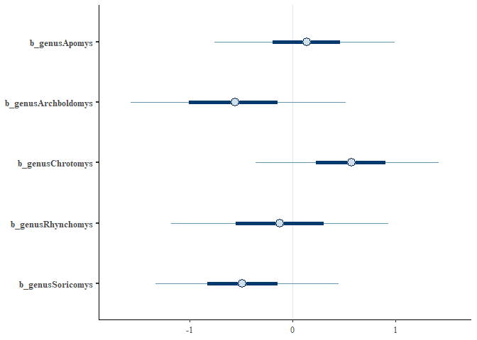

```r
mcmc_plot(ch.44, "^b_", regex = T)
```

Compare: phy/mass (ch.26, all_halfeye), phy only (ch.44), mass only (ch.25,nophy_halfeye).

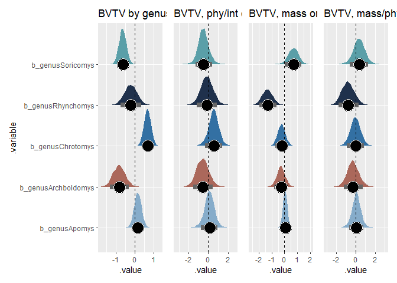

```r
phyonly_halfeye <- ch.44 %>%
  gather_draws(b_genusApomys,b_genusArchboldomys, b_genusChrotomys, b_genusRhynchomys, b_genusSoricomys) %>%
  ggplot(aes(y = .variable, x = .value)) +
  stat_halfeye(aes(fill = .variable),
               point_fill = "#000000",
               shape = 21,
               point_size = 7,
               point_color = "#FFFFFF",
               interval_size = 15,
               interval_color = "grey40",
               .width = .89) +
  scale_fill_manual(values = cols)+
  geom_vline(xintercept = 0, linetype = "dashed")+
  ggtitle(label = "BVTV, phy/int only")+
  theme(legend.position = "none",
        axis.text.y = element_blank(),
        axis.ticks.y = element_blank(),
        axis.title.y = element_blank())
nomass_halfeye|phyonly_halfeye|nophy_halfeye|all_halfeye
```

It’s probably worth doing the other metrics later but for the moment I want to do some intrageneric Chrotomys stuff.